# Usaldusvahemik: praktikum

Indrek Soidla

2022-10-19

Laadime sisse vajalikud paketid.

```r
library(haven)
library(tidyverse)
library(summarytools)
library(survey)
library(srvyr)
library(TAM)
library(matrixStats)
```

## Ülesanne 4.1

### Küsimus

Eelmise teema praktikumieelsetes ülesannetes arvutasime siseriiklike institusioonide usaldusindeksi ja uurisime, kas indeksi aritmeetiline keskmine erineb sõltuvalt sellest, kas enda suhtes diskrimineerimist tajutakse või mitte. Uurime seda täna veel lähemalt, aga arvutage enne indeksi keskmine ja selle usaldusvahemik usaldusnivool 95% ja tõlgendage seda – mida saame keskmise usaldusvahemiku alusel järeldada?

Andmete laadimise ja indeksi koostamise käsud:

```r
r9 <- read_spss("data/ESS9e03_1.sav")
ee9 <- r9 %>%
  filter(cntry == "EE")

ee9 <- ee9 %>%
  mutate(trust = (trstprl + trstlgl + trstplc + trstplt + trstprt) / 5)
```

### Vihje

Kasutades paketti `survey`, on tarvis kõigepealt luua uuringu valimidisaini objekt, seda kasutades saab arvutada ka indeksi keskmise ja standardvea ja nende alusel usalduspiirid.

### Vihje 2

Vaja läheb funktsioone `svydesign`, `svymean` ja `confint`.

### Tulemus

```
##         mean     SE
## trust 5.1183 0.0452
```

```
##          2.5 %   97.5 %
## trust 5.029684 5.206944
```

### Lahendus

```r
ee9 <- ee9 %>%
  mutate(trust = (trstprl + trstlgl + trstplc + trstplt + trstprt) / 5)

ee9w <- svydesign(id = ~1, strata = ~stratum, data = ee9, weights = ~pspwght)

svymean(~trust, design = ee9w, na.rm = TRUE)

svymean(~trust, design = ee9w, na.rm = TRUE) %>%
  confint()
```

Praktikumieelsetes materjalides olid keskmiste ja usalduspiiride arvutamise näited tehtud paketi `survey` abiga. Sel nädalal leidsin, et R-s on ka pakett `srvyr`, mis on analoogne paketile `survey`, aga kasutab meile juba tuttavat `dplyr`’i süntaksit (kus nt ei ole vaja tunnuste nimede ees kasutada `~` sümbolit) ning annab *tibble*-formaadis väljundi. Siin on antud ülesande lahendus `srvyr` funktsioonidega.

```r
ee9 <- ee9 %>%
  mutate(trust = (trstprl + trstlgl + trstplc + trstplt + trstprt) / 5)

ee9 %>%
  as_survey_design(id = 1, strata = stratum, weights = pspwght) %>%
  summarise(trust_keskmine = survey_mean(trust, na.rm = TRUE, vartype = "ci"))
```

```
## # A tibble: 1 × 3
##   trust_keskmine trust_keskmine_low trust_keskmine_upp
##            <dbl>              <dbl>              <dbl>
## 1           5.12               5.03               5.21
```

### Tõlgendus

Usalduse keskmine antud valimis on 5,12 palli. Võttes usaldusvahemiku aruvutuse aluseks usaldusnivoo 95%, saab väita, et usalduse tegelik keskmine on vahemikus 5,03 kuni 5,21 palli.

## Ülesanne 4.2

### Küsimus

Kuidas oleks õige eelnevalt arvutatud usaldusvahemikku tõlgendada? Käesoleva ülesande igal paanil on üks väide ehk usaldusvahemiku tõlgendus, see võib olla õige või vale. Igal järgneval paanil on vastus eelneval paanil oleva väite õigsuse kohta. Seega mõtle iga väite puhul läbi, kas see on õige või vale ja alles seejärel kliki järgmist paani.

### Väide 1

Väide 1: võttes populatsioonist (antud juhul Eesti rahvastikust vanuses 15+ aastat) palju sama suuri juhuvalimeid, oleks nendest 95 puhul sajast usaldusindeksi tegelik keskmine vahemikus 5,03 kuni 5,21 palli.

### Väide 2

Eelmine väide on vale. Keskmise tegelik väärtus ei sõltu valimist, mille võtame, see on kindel väärtus, mis on sama, olenemata sellest, kui palju või millise valimi populatsioonist võtame.

Väide 2: Võttes populatsioonist (antud juhul Eesti rahvastikust vanuses 15+ aastat) palju sama suuri juhuvalimeid, oleks nendest 95 puhul sajast usaldusindeksi keskmine valimis vahemikus 5,03 kuni 5,21 palli.

### Väide 3

Eelmine väide on vale. Meie valim on üks paljudest võimalikest. Keskmise usaldusvahemik arvutatakse valimi, mitte populatsiooni põhjal. Selle põhjal, et ühes valimis on keskmise usaldusvahemik 5,03 kuni 5,21 palli, ei tähenda, et 95% ülejäänud valimitest oleks keskmine selles vahemikus. Valimi põhjal arvutatud usaldusvahemik näitab ainult seda, et eeldatavasti paikneb kuskil selles vahemikus keskmise tegelik väärtus. Tegelik keskmine ei pruugi olla selle usaldusvahemiku keskel nagu antud valimi keskmine, ta võib olla ka nt 5,19. Sellisel juhul ei ole ülejäänud 95% võimalike valimite usalduse keskmine vahemikus 5,03 kuni 5,21 palli, vaid 5,1 kuni 5,28 palli (populatsiooni keskmine +/- 1,96 * standardviga).

Väide 3: 95% indiviidide väärtused on vahemikus 5,03 kuni 5,21 palli.

### Väide 4

Väide 4: usaldusindeksi keskmise tegelik väärtus asub tõenäosusega 95% vahemikus 5,03 kuni 5,21 palli.

### Väide 5

Eelmine väide on vale. Tegelik väärtus on kindel, mitte juhuslik, seega ei saa statistika klassikalise paradigma kohaselt selle suhtes kasutada tõenäosuse mõistet. Tegelik väärtus ei paikne kuskil mingi tõenäosusega ega ole juhuslik; juhuslik on hoopis valim, seetõttu saab tõenäosuse mõistet kasutada valimi ja selle alusel leitava statistiku ja selle usaldusvahemiku kohta.

Väide 5: valimi alusel arvutatav usaldusindeksi keskmine asub tõenäosusega 95% vahemikus 5,03 kuni 5,21 palli.

### Väide 6

Eelmine väide on vale. Antud valimi usaldusindeksi keskmine on niigi teada, see on 5,12 palli. Kui rääkida kõikidest muudest võimalikest valimitest, siis vaata väite 2 selgitust.

Väide 6: kui võtame populatsioonist palju sama suuri juhuvalimeid, siis nendest 95 puhul sajast kataks usaldusnivool 95% arvutatud usaldusvahemik usaldusindeksi tegeliku keskmise.

### Väide 7

Eelmine väide on õige. Siiski võib sellegi tõlgenduse täpsuse huvides olla vajalik teha teatud mööndusi - küsitlusuuringute puhul esineb alati mingi esinduslikkuse või mõõtmisega seotud viga, mis võib tuleneda näiteks sellest, et kõik võetud valimi liikmed ei vasta või et ankeediküsimus ei mõõda uuritavat konstrukti täiesti täpselt või et osad intervjueerijad mõjutavad teadlikult või teadmata oma käitumisega (või isegi isikuga) vastajate vastuseid. Seega väita, et uuritav kogum on täiesti juhuslik kogum populatsioonist, ei ole enamasti päris realistlik.

Väide 7: kui võtame populatsioonist palju sama suuri juhuvalimeid, siis nendest maksimaalselt 5 puhul sajast ei kataks usaldusnivool 95% arvutatud usaldusvahemik usaldusindeksi tegelikku keskmist.

### Vastus

Eelmine väide on samuti õige. Tegu on väite 6 ümberpööratud sõnastusega.

Kokkuvõtteks: eelnevatest väidetest olid õiged ainult kaks viimast. Kui panite enamiku väidetega puusse, siis ärge heituge: uuringud on näidanud, et isegi ülikoolide teadustöötajatest suur osa eksiks vähemalt mõne väite puhul. See siiski ei tähenda, et selgele sõnastusele võiks käega lüüa - kui tõlgendamise põhialustes on segadus, esineb arvestatav risk, et eksitame oma tõlgendustega ka teisi, kes on usaldusvahemikega ja uuringutulemuste tõlgendamisega veel vähem kokku puutunud.

## Ülesanne 4.3

### Küsimus

Uurime veel usaldust siseriiklike institutsioonide vastu. Uurige, milline võib olla meeste ja naiste usaldusindeksi keskmine.

1. Arvutage meeste ja naiste keskmiste usalduspiirid usaldusnivool 95%. Millises vahemikus võivad keskmiste tegelikud väärtused populatsioonis olla?
2. Kas usaldusvahemikud on kitsamad või laiemad kui eelnevalt kõigi vastajate pealt arvutatud usaldusvahemik? Miks see nii on?
3. Esitage keskmised ja usaldusvahemikud ka vahemikdiagrammil. Kas on alust väita keskmiste erinevust populatsioonis?
4. Arvutage keskmiste usalduspiirid ka usaldusnivoodel 90% ja 99%. Kas kõigil usaldusnivoodel on alust väita keskmiste erinevust populatsioonis? Kui erinevust saab väita, siis kas on alust ka sisulises plaanis oluliste erinevuste väitmiseks?
5. Kes soovib, võib proovida panna ühele joonisele kõigil usaldusnivoodel arvutatud usaldusvahemikud - praktikas seda eriti ei tehta, aga uurimaks, kuidas erinevatel usaldusnivoodel arvutatud usaldusvahemikud üksteisest erinevad ja mida saab nende alusel järeldada meeste ja naiste keskmiste erinevust kohta, on visuaalne lahendus asjakohane. Tuletagem meelde, et `ggplot` võimaldab ühele diagrammile paigutada kokku väga erinevaid visuaalseid elemente ehk `geom`-e. Erinevatel usaldusnivoodel arvutatud usaldusvahemikud saab ggploti käsku panna eraldi geom_errorbar käskudega (st kokku kolm käsku). Kuna usaldusvahemikud jäävad osaliselt üksteise peale, oleks mõttekas nad eristada värviga ja miks mitte ka joone paksusega.

### Tulemus

Väljund paketiga `survey`

```
##         gndr2    trust     ci_l     ci_u
## Mehed   Mehed 4.924559 4.788345 5.060772
## Naised Naised 5.286743 5.174791 5.398695
```

Väljund paketiga `srvyr`

```
## # A tibble: 2 × 4
##   gndr2  trust_keskmine trust_keskmine_low trust_keskmine_upp
##   <fct>           <dbl>              <dbl>              <dbl>
## 1 Mehed            4.92               4.79               5.06
## 2 Naised           5.29               5.17               5.40
```

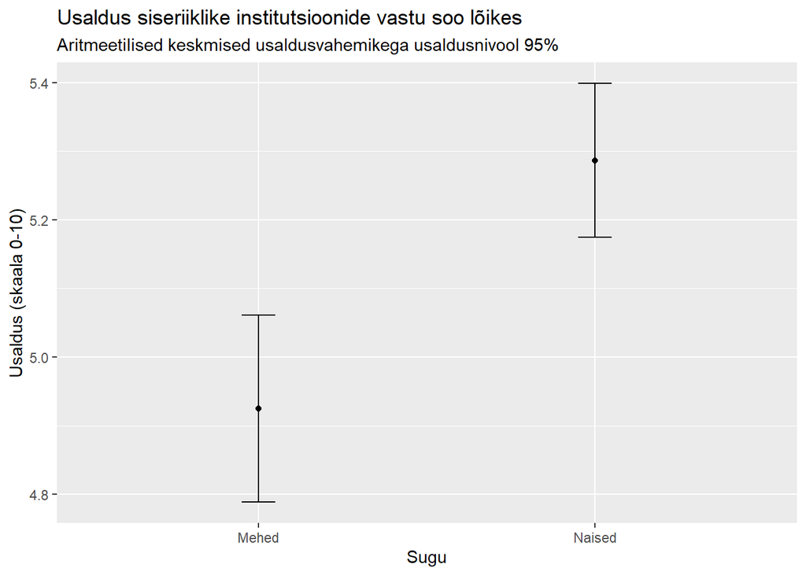

```
## # A tibble: 2 × 10
##   gndr2  trust_keskmine_90 trust_keskmine_90_low trust_keskmine_90_upp
##   <fct>              <dbl>                 <dbl>                 <dbl>
## 1 Mehed               4.92                  4.81                  5.04
## 2 Naised              5.29                  5.19                  5.38
## # ℹ 6 more variables: trust_keskmine_95 <dbl>, trust_keskmine_95_low <dbl>,
## #   trust_keskmine_95_upp <dbl>, trust_keskmine_99 <dbl>,
## #   trust_keskmine_99_low <dbl>, trust_keskmine_99_upp <dbl>
```

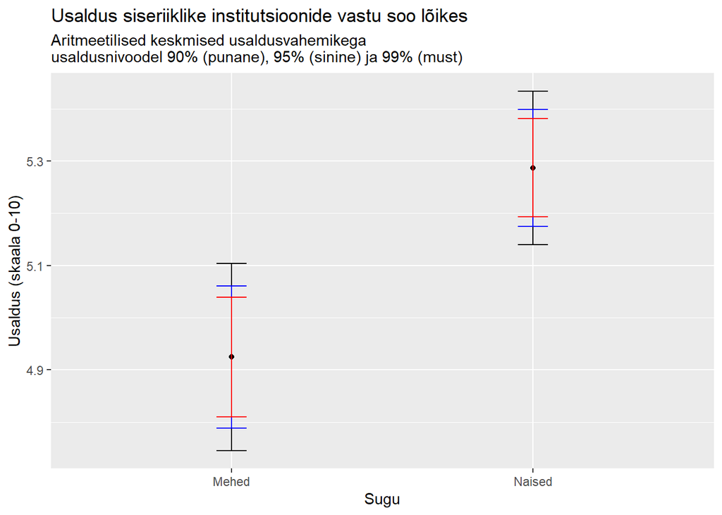

### Lahendus

Lahendus paketiga `survey`

```r
ee9 <- ee9 %>%
  mutate(gndr2 = recode(as.factor(gndr),
                        "1" = "Mehed",
                        "2" = "Naised"))

ee9w <- svydesign(id = ~1, strata = ~stratum, data = ee9, weights = ~pspwght)
svyby(~trust, ~gndr2, design = ee9w, FUN = svymean, na.rm = TRUE, vartype = c("ci"))
```

```r
svyby(~trust, ~gndr2, design = ee9w, FUN = svymean, na.rm = TRUE, vartype = c("ci")) %>%
  ggplot(aes(x = gndr2, y = trust)) +
  geom_point() +
  geom_errorbar(aes(ymin = ci_l, ymax = ci_u), width = 0.1) +
  labs(title = "Usaldus siseriiklike institutsioonide vastu soo lõikes",
       subtitle = "Aritmeetilised keskmised usaldusvahemikega usaldusnivool 95%",
       x = "Sugu",
       y = "Usaldus (skaala 0-10)")
```

Lahendus paketiga `srvyr` + joonis usaldusvahemikega erinevatel usaldusnivoodel

```r
ee9 <- ee9 %>%
  mutate(gndr2 = recode(as.factor(gndr),
                        "1" = "Mehed",
                        "2" = "Naised"))

ee9 %>%
  as_survey_design(id = 1, strata = stratum, weights = pspwght) %>%
  group_by(gndr2) %>%
  summarise(trust_keskmine = survey_mean(trust, na.rm = TRUE, vartype = "ci"))

ee9 %>%
  as_survey_design(id = 1, strata = stratum, weights = pspwght) %>%
  group_by(gndr2) %>%
  summarise(trust_keskmine = survey_mean(trust, na.rm = TRUE, vartype = "ci")) %>%
ggplot(aes(x = gndr2, y = trust_keskmine)) +
  geom_point() +
  geom_errorbar(aes(ymin = trust_keskmine_low, ymax = trust_keskmine_upp), width = 0.1) +
  labs(title = "Usaldus siseriiklike institutsioonide vastu soo lõikes",
       subtitle = "Aritmeetilised keskmised usaldusvahemikega usaldusnivool 95%",
       x = "Sugu",
       y = "Usaldus (skaala 0-10)")

trust_ci_levels <- ee9 %>%
  as_survey_design(id = 1, strata = stratum, weights = pspwght) %>%
  group_by(gndr2) %>%
  summarise(trust_keskmine_90 = survey_mean(trust, na.rm = TRUE, vartype = "ci", level = 0.9),
            trust_keskmine_95 = survey_mean(trust, na.rm = TRUE, vartype = "ci", level = 0.95),
            trust_keskmine_99 = survey_mean(trust, na.rm = TRUE, vartype = "ci", level = 0.99))

trust_ci_levels

trust_ci_levels %>%
ggplot(aes(x = gndr2, y = trust_keskmine_95)) +
  geom_point() +
  geom_errorbar(aes(ymin = trust_keskmine_99_low, ymax = trust_keskmine_99_upp), width = 0.1) +
  geom_errorbar(aes(ymin = trust_keskmine_95_low, ymax = trust_keskmine_95_upp), width = 0.1, colour = "blue") +
  geom_errorbar(aes(ymin = trust_keskmine_90_low, ymax = trust_keskmine_90_upp), width = 0.1, colour = "red") +
  labs(title = "Usaldus siseriiklike institutsioonide vastu soo lõikes",
       subtitle = "Aritmeetilised keskmised usaldusvahemikega\nusaldusnivoodel 90% (punane), 95% (sinine) ja 99% (must)",
       x = "Sugu",
       y = "Usaldus (skaala 0-10)")
```

## Ülesanne 4.4

### Küsimus

Läheme tagasi eelmise korra praktikumieelse ülesande juurde, kus arvutasite usaldusindeksi jaotusparameetrid diskrimineerimise tajumise lõikes. Arvutage nüüd nende kahe grupi puhul lisaks keskmistele ka keskmiste usaldusvahemikud usaldusnivool 95% ja esitage need joonisel.

1. Millise järelduse tegite eelmine kord usaldustaseme erinevuse kohta kahes grupis ainult keskmiste põhjal, millise teeksite nüüd, vaadates lisaks ka keskmiste usaldusvahemikke?
2. Nende puhul, kes enda suhtes diskrimineerimist tajuvad, on usaldusindeksi keskmise usaldusvahemik märkimisväärselt laiem. Miks see nii võib olla, miks on nende keskmise hinnangu puhul n-ö määramatust oluliselt rohkem?

### Tulemus

Väljund paketiga `survey`

```
##         dscrgrp2    trust     ci_l     ci_u
## Tajub      Tajub 4.421420 4.074270 4.768569
## Ei taju  Ei taju 5.179351 5.088524 5.270178
```

Väljund paketiga `srvyr`

```
## # A tibble: 3 × 4
##   dscrgrp2 trust_keskmine trust_keskmine_low trust_keskmine_upp
##   <fct>             <dbl>              <dbl>              <dbl>
## 1 Tajub              4.42               4.07               4.77
## 2 Ei taju            5.18               5.09               5.27
## 3 <NA>               4.2                4.2                4.2
```

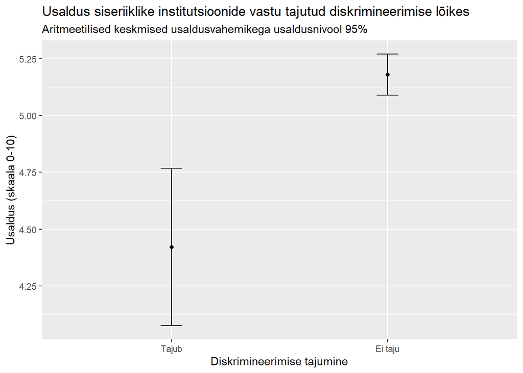

Usalduse jaotusparameetrid tajutud diskrimineerimise lõikes (võib olla vajalik b-küsimusele vastamiseks)

```
## # A tibble: 2 × 13
##   dscrgrp2 keskmine   std alum_kvart mediaan ylem_kvart   iqr   mad   min   max
##   <fct>       <dbl> <dbl>      <dbl>   <dbl>      <dbl> <dbl> <dbl> <dbl> <dbl>
## 1 Tajub        4.42  2.03          3     4.6        6     3     1.4     0   8.2
## 2 Ei taju      5.18  1.85          4     5.4        6.6   2.6   1.2     0  10
##    asymm jarskus   arv
##    <dbl>   <dbl> <dbl>
## 1 -0.386  -0.591  149.
## 2 -0.346  -0.195 1708.
```

### Lahendus

Lahendus paketiga `survey`

```r
ee9 <- ee9 %>%
  mutate(dscrgrp2 = recode(as.factor(dscrgrp),
                        "1" = "Tajub",
                        "2" = "Ei taju"))

ee9w <- svydesign(id = ~1, data = ee9, weights = ~pspwght)
svyby(~trust, ~dscrgrp2, design = ee9w, FUN = svymean, na.rm = TRUE, vartype = "ci")
```

```r
svyby(~trust, ~dscrgrp2, design = ee9w, FUN = svymean, na.rm = TRUE, vartype = "ci") %>%
  ggplot(aes(dscrgrp2, trust)) +
  geom_point() +
  geom_errorbar(aes(ymin = ci_l, ymax = ci_u), width = 0.1) +
  labs(title = "Usaldus siseriiklike institutsioonide vastu tajutud diskrimineerimise lõikes",
       subtitle = "Aritmeetilised keskmised usaldusvahemikega usaldusnivool 95%",
       x = "Diskrimineerimise tajumine",
       y = "Usaldus (skaala 0-10)")
```

Lahendus paketiga `srvyr`

```r
ee9 <- ee9 %>%
  mutate(dscrgrp2 = recode(as.factor(dscrgrp),
                        "1" = "Tajub",
                        "2" = "Ei taju"))

trust_ci_dscrgrp <- ee9 %>%
  as_survey_design(id = 1, strata = stratum, weights = pspwght) %>%
  group_by(dscrgrp2) %>%
  summarise(trust_keskmine = survey_mean(trust, na.rm = TRUE, vartype = "ci"))

trust_ci_dscrgrp
```

```
## # A tibble: 3 × 4
##   dscrgrp2 trust_keskmine trust_keskmine_low trust_keskmine_upp
##   <fct>             <dbl>              <dbl>              <dbl>
## 1 Tajub              4.42               4.07               4.77
## 2 Ei taju            5.18               5.09               5.27
## 3 <NA>               4.2                4.2                4.2
```

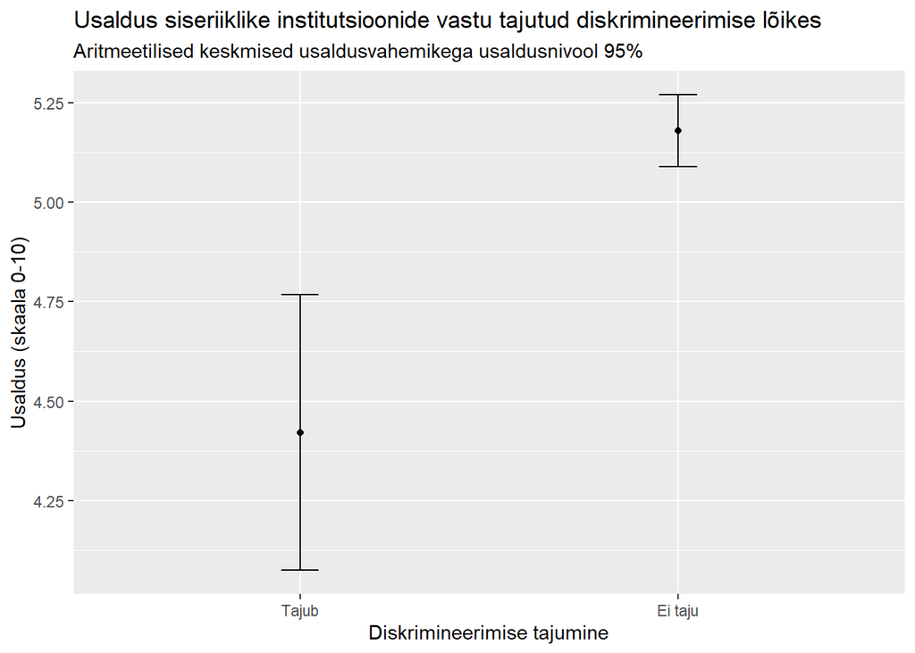

```r
trust_ci_dscrgrp %>%
  drop_na(dscrgrp2) %>%
  ggplot(aes(x = dscrgrp2, y = trust_keskmine)) +
  geom_point() +
  geom_errorbar(aes(ymin = trust_keskmine_low, ymax = trust_keskmine_upp), width = 0.1) +
  labs(title = "Usaldus siseriiklike institutsioonide vastu tajutud diskrimineerimise lõikes",
       subtitle = "Aritmeetilised keskmised usaldusvahemikega usaldusnivool 95%",
       x = "Diskrimineerimise tajumine",
       y = "Usaldus (skaala 0-10)")
```

Usaldusindeksi jaotusparameetrid

```r
ee9 %>%
  drop_na(trust, dscrgrp2) %>%
  group_by(dscrgrp2) %>%
  summarise(keskmine = weighted_mean(trust, w = pspwght),
            std = weighted_sd(trust, w = pspwght),
            alum_kvart = weighted_quantile(trust, w = pspwght, probs = 0.25),
            mediaan = weighted_quantile(trust, w = pspwght, probs = 0.5),
            ylem_kvart = weighted_quantile(trust, w = pspwght, probs = 0.75),
            iqr = ylem_kvart - alum_kvart,
            mad = weightedMad(trust, constant = 1),
            min = min(trust),
            max = max(trust),
            asymm = weighted_skewness(trust, w = pspwght),
            jarskus = weighted_kurtosis(trust, w = pspwght),
            arv = sum(pspwght)) %>%
  print(width = Inf)
```

## Ülesanne 4.5

### Küsimus

Arvutage paketi `srvyr` abiga Euroopa Sotsiaaluuringu Suurbritannia 10. laine andmete põhjal tunnuse impcntr (hinnang selle kohta, kui palju sisserändajaid peaks Suurbritanniasse lubama vaesematest riikidest väljastpoolt Euroopat) protsentjaotus koos protsentnäitajate usalduspiiridega, võttes arvesse valikudisaini ja kaaludes andmeid järelkihistuskaalu tunnusega.

Mis tüüpi valimiga on Suurbritannia puhul tegu? Saate selle kohta infot [ESS-i andmeportaalist](https://ess-search.nsd.no/en/study/172ac431-2a06-41df-9dab-c1fd8f3877e7) (*Country Documentation* => *United Kingdom*). Millised funktsiooni `as_survey_design` argumendid peaksid sellest tulenevalt valikudisaini seadistamisel kirjas olema?

Kui suureks saab hinnata nende inimeste osakaalu Suurbritannias, kes ei lubaks riiki ühtegi sisserändajat vaesematest riikidest väljastpoolt Euroopat? Kui suureks saab hinnata nende osakaalu, kes lubaksid riiki palju selliseid sisserändajaid?

### Tulemus

```
## # A tibble: 5 × 4
##   impcntr                                 prop prop_low prop_upp
##   <dbl+lbl>                              <dbl>    <dbl>    <dbl>
## 1  1 [Allow many to come and live here] 0.307   0.275     0.341
## 2  2 [Allow some]                       0.478   0.439     0.516
## 3  3 [Allow a few]                      0.165   0.140     0.193
## 4  4 [Allow none]                       0.0385  0.0289    0.0509
## 5 NA                                    0.0122  0.00664   0.0224
```

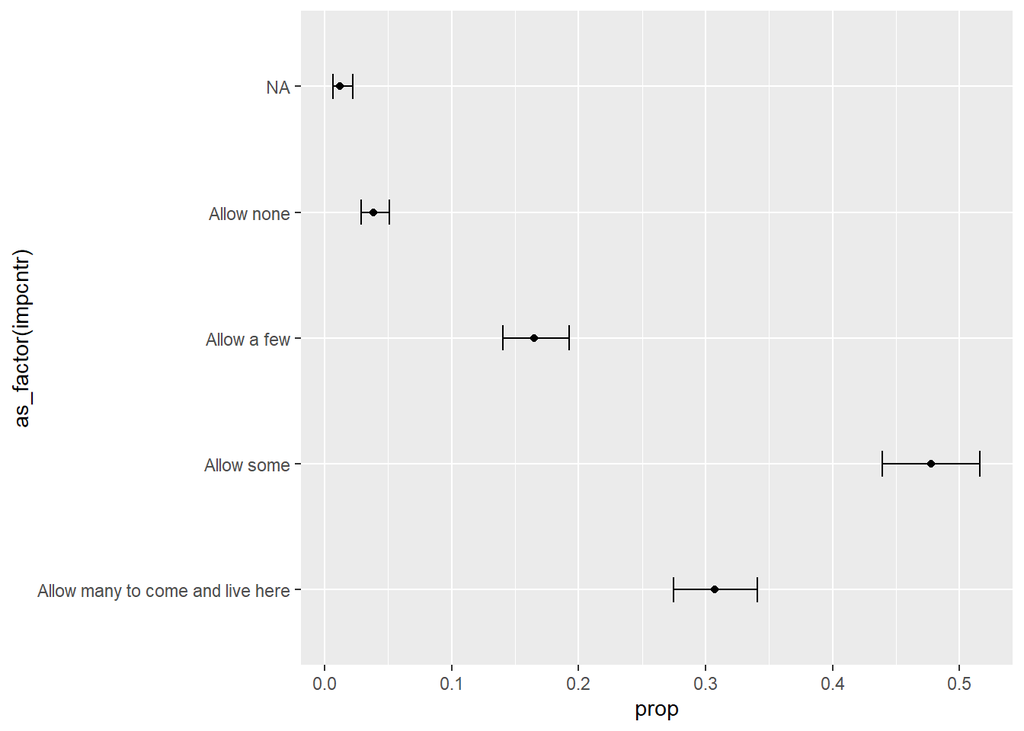

### Lahendus

```r
ess10 <- read_spss("data/ess10.sav")

impcntr_gb <- ess10 %>%
  filter(cntry == "GB") %>%
  as_survey_design(ids = psu, strata = stratum, weights = pspwght) %>%
  group_by(impcntr) %>%
  summarise(prop = survey_prop(vartype = "ci"))

impcntr_gb

impcntr_gb %>%
  ggplot(aes(x = prop, y = as_factor(impcntr))) +
  geom_point() +
  geom_errorbar(aes(xmin = prop_low, xmax = prop_upp), width = 0.2)
```